# Drawing production analyses: main analyses, Figure 3/4

Bria Long

9/23/2020, finalized 7/2023

# Libraries and setup

```r
# set seed for reproducibility
set.seed(123)
```

# Load main data

## VGG and CLIP classifications

```r
load(file=here::here('data/preprocessed_data/merged_vgg_class_and_meta.RData'))
# for each layer
load(file=here::here('data/preprocessed_data/vgg_outputs_by_layer.RData'))
```

```r
load(file=here::here('data/preprocessed_data/merged_clip_class_and_meta.RData'))
drawn_categories = unique(d_clip$category)
```

# Drawing recognition increases with age

## Full model predicting accuracy for all drawings

```r
all_covariates_accuracy <- glmer(data=d, correct_or_not ~ scale(age_numeric)*scale(drawing_frequency)+scale(avg_tracing_rating) + scale(draw_duration) +
                          scale(mean_intensity) +
                          scale(num_strokes) +
                        (1|session_id) +
                        (1|category), family="binomial",control=glmerControl(optimizer="bobyqa",optCtrl=list(maxfun=2e4)))
```

Plot residuals for main predictor (age)

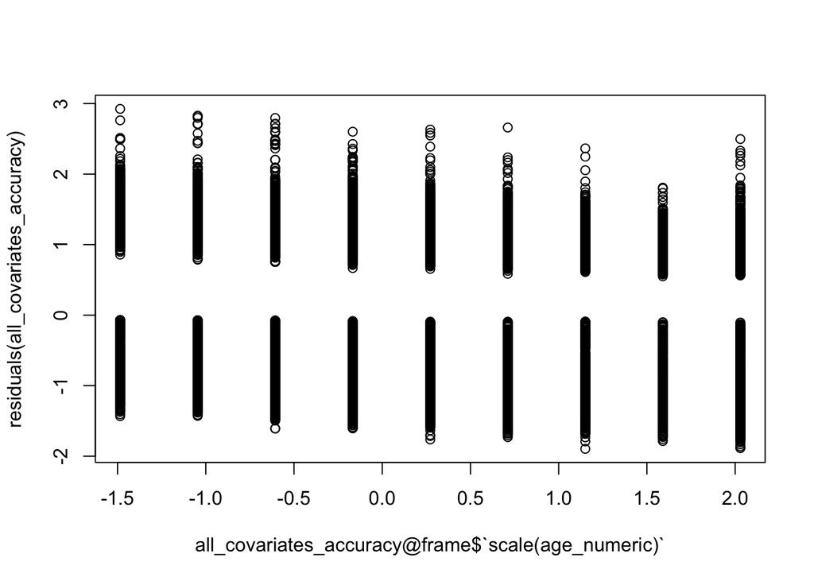

```r
plot(residuals(all_covariates_accuracy) ~ all_covariates_accuracy@frame$`scale(age_numeric)`)
```

Check random effects distribution

```r
ranef_plot <- ranef(all_covariates_accuracy, condVar = TRUE)
```

Plot residuals.

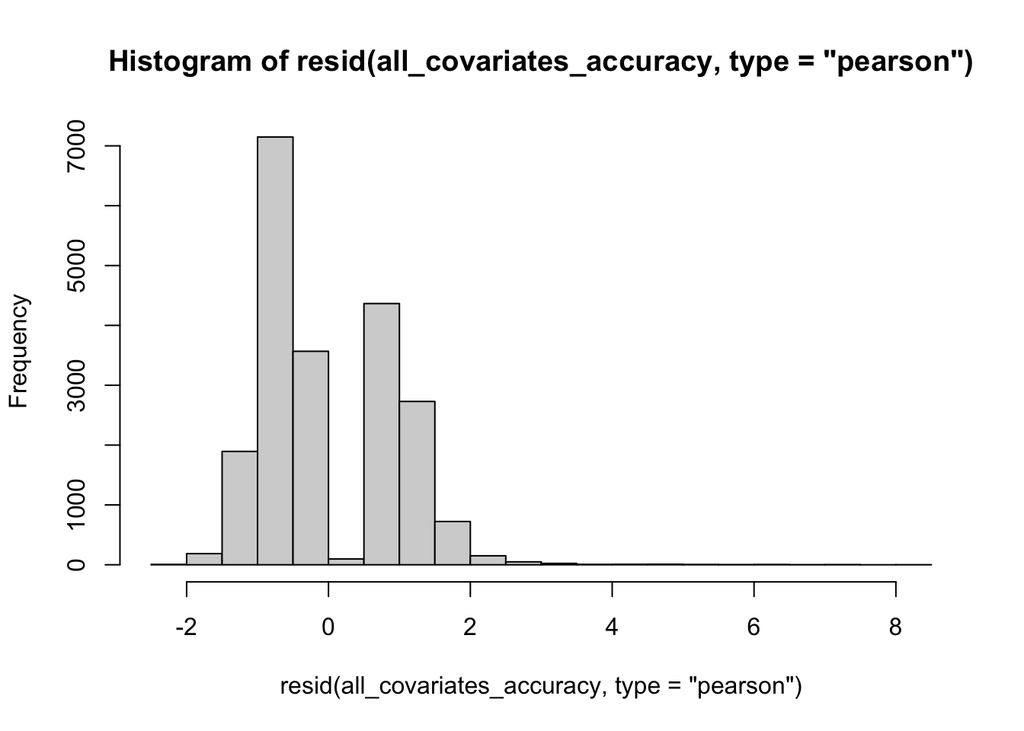

```r
hist(resid(all_covariates_accuracy, type = "pearson"))
```

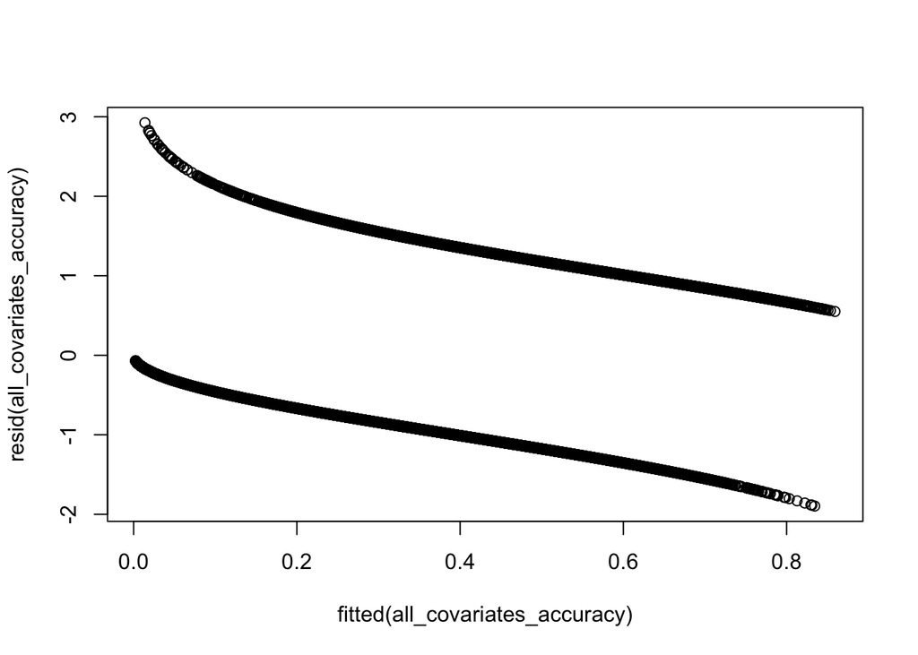

```r
plot(resid(all_covariates_accuracy)~fitted(all_covariates_accuracy))
```

```r
fixed_effect_length = length(summary(all_covariates_accuracy)$coef[,1])
```

```r
ci_table1 = confint(all_covariates_accuracy, method='Wald')
```

```r
summary_model <- summary(all_covariates_accuracy)

summary_table_complete <- cbind(Estimate = sprintf("%.3f",round(summary_model$coefficients[, "Estimate"],3)),
                                `Std. Error` = sprintf("%.3f",round(summary_model$coefficients[, "Std. Error"],3)),
                                `z value` = sprintf("%.3f",round(summary_model$coefficients[, "z value"],3)),
                                `Pr(>|z|)` = format.pval(summary_model$coefficients[, "Pr(>|z|)"],eps=0.0001,scientific = FALSE, digits=2),
                                 `2.5 % CI` = sprintf("%.3f",round(ci_table1[3:10, 1],3)),
                                `97.5 % CI` = sprintf("%.3f",round(ci_table1[3:10, 2],3)))
```

```r
rownames(summary_table_complete) = c('Intercept','Age (in years)','Est. drawing frequency','Avg tracing rating','Time spent drawing','Ink used','Number of strokes','Age*drawing frequency')
```

### Table 1

```r
xtable::xtable(as.data.frame(summary_table_complete), digits=4, caption = " \textbf{Modeling children's visual production behavior.}Results of a generalized linear mixed-effect model predicting the recognizability of each drawing (i.e. binary classification scores) from VGG-19 FC6 classifications, including random intercepts for each category and participant. All predictors were z-scored prior to analysis such that coefficients are standardized and comparable. All significance tests are Wald significance tests based on the coefficient values; these tests are two-tailed. No adjustments were made for multiple comparisons. See textit{Methods} for further model specifications.")
```

```
## % latex table generated in R 4.3.1 by xtable 1.8-4 package
## % Thu Jan 18 15:21:41 2024
## \begin{table}[ht]
## \centering
## \begin{tabular}{rllllll}
##   \hline
##  & Estimate & Std. Error & z value & Pr($>$$|$z$|$) & 2.5 \% CI & 97.5 \% CI \\
##   \hline
## Intercept & -0.690 & 0.173 & -3.979 & $<$0.0001 & -1.030 & -0.350 \\
##   Age (in years) & 0.251 & 0.020 & 12.805 & $<$0.0001 & 0.212 & 0.289 \\
##   Est. drawing frequency & -0.062 & 0.173 & -0.356 & 0.721 & -0.402 & 0.278 \\
##   Avg tracing rating & 0.267 & 0.020 & 13.529 & $<$0.0001 & 0.229 & 0.306 \\
##   Time spent drawing & 0.039 & 0.021 & 1.868 & 0.062 & -0.002 & 0.079 \\
##   Ink used & -0.031 & 0.020 & -1.546 & 0.122 & -0.070 & 0.008 \\
##   Number of strokes & 0.008 & 0.018 & 0.477 & 0.634 & -0.026 & 0.043 \\
##   Age*drawing frequency & 0.017 & 0.017 & 1.042 & 0.298 & -0.015 & 0.050 \\
##    \hline
## \end{tabular}
## \caption{    extbf{Modeling children's visual production behavior.}Results of a generalized linear mixed-effect model predicting the recognizability of each drawing (i.e. binary classification scores) from VGG-19 FC6 classifications, including random intercepts for each category and participant. …
## \end{table}
```

### Appendix Table: multicolinearity

```r
# https://easystats.github.io/blog/posts/performance_check_collinearity/#:~:text=Multicollinearity%20%E2%80%9Cis%20a%20phenomenon%20in,as%20non%2Dindependent%20covariates).
library(performance)
out = check_collinearity(all_covariates_accuracy)
xtable::xtable(out)
```

```
## % latex table generated in R 4.3.1 by xtable 1.8-4 package
## % Thu Jan 18 15:21:42 2024
## \begin{table}[ht]
## \centering
## \begin{tabular}{rlrrrrrrr}
##   \hline
##  & Term & VIF & VIF\_CI\_low & VIF\_CI\_high & SE\_factor & Tolerance & Tolerance\_CI\_low & Tolerance\_CI\_high \\
##   \hline
## 1 & scale(age\_numeric) & 1.26 & 1.24 & 1.28 & 1.12 & 0.79 & 0.78 & 0.81 \\
##   2 & scale(drawing\_frequency) & 1.00 & 1.00 & Inf & 1.00 & 1.00 & 0.00 & 1.00 \\
##   3 & scale(avg\_tracing\_rating) & 1.24 & 1.22 & 1.26 & 1.11 & 0.81 & 0.79 & 0.82 \\
##   4 & scale(draw\_duration) & 1.30 & 1.28 & 1.32 & 1.14 & 0.77 & 0.76 & 0.78 \\
##   5 & scale(mean\_intensity) & 1.29 & 1.27 & 1.31 & 1.14 & 0.78 & 0.76 & 0.79 \\
##   6 & scale(num\_strokes) & 1.07 & 1.05 & 1.08 & 1.03 & 0.94 & 0.92 & 0.95 \\
##   7 & scale(age\_numeric):scale(drawing\_frequency) & 1.01 & 1.00 & 1.06 & 1.00 & 0.99 & 0.95 & 1.00 \\
##    \hline
## \end{tabular}
## \end{table}
```

## Validation: with CLIP

```r
all_covariates_accuracy_clip <- glmer(correct_or_not ~ scale(age_numeric)*scale(drawing_frequency)+scale(avg_tracing_rating) + scale(draw_duration) +
                          scale(mean_intensity) +
                          scale(num_strokes) +
                        (1|session_id) +
                        (1|category),
      data = d_clip, family="binomial",control=glmerControl(optimizer="bobyqa",optCtrl=list(maxfun=2e4)))
```

```r
cis_clip_production = confint(all_covariates_accuracy_clip, method='Wald')
```

```r
summary_model <- summary(all_covariates_accuracy_clip)

summary_table_complete <- cbind(Estimate = sprintf("%.3f",round(summary_model$coefficients[, "Estimate"],3)),
                                `Std. Error` = sprintf("%.3f",round(summary_model$coefficients[, "Std. Error"],3)),
                                `z value` = sprintf("%.3f",round(summary_model$coefficients[, "z value"],3)),
                                `Pr(>|z|)` = format.pval(summary_model$coefficients[, "Pr(>|z|)"],eps=0.0001,scientific = FALSE, digits=2),
                                 `2.5 % CI` = sprintf("%.3f",round(cis_clip_production[3:10, 1],3)),
                                `97.5 % CI` = sprintf("%.3f",round(cis_clip_production[3:10, 2],3)))
```

```r
rownames(summary_table_complete) = c('Intercept','Age (in years)','Est. drawing frequency','Avg tracing rating','Time spent drawing','Ink used','Number of strokes','Age*drawing frequency')
```

### Appendix: CLIP classifications

```r
xtable::xtable(summary_table_complete, digits=4, caption = "Model coefficients of a GLMM predicting the recognizability of each drawing (i.e. binary classification scores) from CLIP classifications, including random intercepts for each category and participant.")
```

```
## % latex table generated in R 4.3.1 by xtable 1.8-4 package
## % Thu Jan 18 15:22:15 2024
## \begin{table}[ht]
## \centering
## \begin{tabular}{rllllll}
##   \hline
##  & Estimate & Std. Error & z value & Pr($>$$|$z$|$) & 2.5 \% CI & 97.5 \% CI \\
##   \hline
## Intercept & -1.319 & 0.178 & -7.410 & $<$0.0001 & -1.668 & -0.970 \\
##   Age (in years) & 0.329 & 0.019 & 17.225 & $<$0.0001 & 0.291 & 0.366 \\
##   Est. drawing frequency & 0.274 & 0.177 & 1.551 & 0.1209 & -0.072 & 0.620 \\
##   Avg tracing rating & 0.279 & 0.020 & 14.320 & $<$0.0001 & 0.241 & 0.318 \\
##   Time spent drawing & 0.195 & 0.019 & 10.065 & $<$0.0001 & 0.157 & 0.233 \\
##   Ink used & 0.048 & 0.018 & 2.705 & 0.0068 & 0.013 & 0.083 \\
##   Number of strokes & 0.070 & 0.030 & 2.338 & 0.0194 & 0.011 & 0.129 \\
##   Age*drawing frequency & 0.029 & 0.014 & 2.030 & 0.0423 & 0.001 & 0.057 \\
##    \hline
## \end{tabular}
## \caption{Model coefficients of a GLMM predicting the recognizability of each drawing (i.e. binary classification scores) from CLIP classifications, including random intercepts for each category and participant.}
## \end{table}
```

# More frequently drawn categories are not more recognizable.

## Load, anlayze, and plot category frequency ratings

```r
frequency = read_csv(file = here::here('data/surveys/drawing_experience/preprocessed/Category_frequency_survey.csv'))
```

```r
count_by_age <- frequency %>%
  group_by(childs_age) %>%
  dplyr::summarize(num_surveys = length(unique(subject_id)))
```

```r
freq_by_category_temp<- frequency %>%
  # filter(childs_age > 2) %>%
  mutate(category = str_split_fixed(category,' ',2)[,2]) %>%
  mutate(category = str_replace(category,' ','.')) %>%
  filter(category %in% drawn_categories)

freq_by_category <- freq_by_category_temp %>%
  group_by(category) %>%
  summarize(drawing_frequency = mean(often_drawn_rating))

# write_csv(freq_by_category, here::here('data/surveys/drawing_experience/preprocessed/freq_by_category.csv'))
```

```r
freq_by_category_plot <- freq_by_category_temp %>%
  group_by(category, childs_age) %>%
  multi_boot_standard(col = 'often_drawn_rating') %>%
  ungroup() %>%
  mutate(category = fct_reorder(category, mean, .desc=TRUE))

freq_by_category_by_age <- freq_by_category_temp %>%
  group_by(category, childs_age) %>%
  summarize(frequency = mean(often_drawn_rating))
```

```r
# summary(lm(data=freq_by_category_by_age, frequency ~ childs_age*category))
```

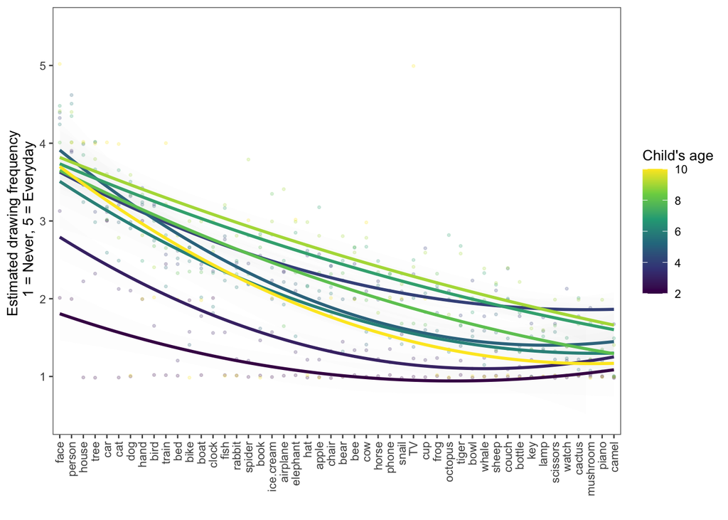

```r
ggplot(freq_by_category_plot, aes(x=category, y=mean, col=childs_age)) +
  theme_few(base_size=10)+
  geom_jitter(height=.02, width=0, alpha=.2, size=.6)+
  theme(axis.text.x = element_text(angle = 90, vjust = 0.5, hjust=1)) +
  labs(y = 'Estimated drawing frequency \n 1 = Never, 5 = Everyday', x  = '') +
  ylim(.5,5.5) +
  geom_smooth(aes(group=childs_age),alpha=.02, span=10) +
  scale_color_viridis_c(name = 'Child\'s age') +
  theme(legend.position = 'right')
```

```r
ggsave(here::here('data/figures_out/Appendix_A6_estimated_frequency.pdf'), units='in', height=4, width=8)

write_csv(freq_by_category_plot, file = here::here('data/figures_csvs/Appendix_A6_estimated_frequency.csv'))
```

## Load other measures of frequency

```r
aoas <- readRDS(file=here::here('data/category_features/english_(american)_aoa_bydefinition.rds')) %>%
  filter(measure=="produces") %>%
  filter(definition %in% drawn_categories) %>%
  rename(word = definition)
```

```r
load(file = here::here('data/category_features/merged_word_freqs.Rdata'))
category_by_word_freq <- ch_freq_smooth %>%
  filter(word %in% drawn_categories) %>%
  filter(lexical_class == 'nouns') %>%
  distinct(word, on_cdi, CHILDES, adult_books)
```

### Join all frequnecy data together

```r
all_freq_by_category <-  freq_by_category %>%
  left_join(category_by_word_freq, by=c('category' = 'word')) %>%
  left_join(aoas %>% select(word, aoa), by=c('category' = 'word'))
```

```r
d_with_freq <- d %>%
  left_join(all_freq_by_category)
```

```r
all_freq_covariates <-  glmer(correct_or_not ~ scale(age_numeric)+scale(adult_books) + scale(aoa) + scale(CHILDES) + scale(drawing_frequency) +
                        (1|session_id) +
                        (1|category),
      data = d_with_freq , family="binomial",control=glmerControl(optimizer="bobyqa",optCtrl=list(maxfun=2e4)))

cis_freq = confint(all_freq_covariates, method='Wald')
```

```r
summary_model = summary(all_freq_covariates)

summary_table_complete_freq <- cbind(Estimate = sprintf("%.3f",round(summary_model$coefficients[, "Estimate"],3)),
                                `Std. Error` = sprintf("%.3f",round(summary_model$coefficients[, "Std. Error"],3)),
                                `z value` = sprintf("%.3f",round(summary_model$coefficients[, "z value"],3)),
                                `Pr(>|z|)` = format.pval(summary_model$coefficients[, "Pr(>|z|)"],eps=0.0001,scientific = FALSE, digits=2),
                                 `2.5 % CI` = sprintf("%.3f",round(cis_freq[3:8, 1],3)),
                                `97.5 % CI` = sprintf("%.3f",round(cis_freq[3:8, 2],3)))

rownames(summary_table_complete_freq)=c('Intercept','Age (in years)','Freq in adult books','Age-of-Acquisition','CHILDES frequency','Drawing frequency')
```

## Appendix: Table A5: No effect of other frequency measures on recognizability

```r
xtable::xtable(summary_table_complete_freq, digits=3, caption = "Model coefficients of a GLMM predicting the recognizability of each drawing (i.e. binary classification scores) from children's age, the frequency of each category in CHILDES (data for 91.8 percent of categories), the estimated Age-of-Aquisition using WordBank data (data for 73 percent of categories), and the frequency of each word in adult English books. All predictors are z-scored; random intercepts for each category and participant are included.")
```

```
## % latex table generated in R 4.3.1 by xtable 1.8-4 package
## % Thu Jan 18 15:22:29 2024
## \begin{table}[ht]
## \centering
## \begin{tabular}{rllllll}
##   \hline
##  & Estimate & Std. Error & z value & Pr($>$$|$z$|$) & 2.5 \% CI & 97.5 \% CI \\
##   \hline
## Intercept & -0.965 & 0.237 & -4.065 & $<$0.0001 & -1.430 & -0.500 \\
##   Age (in years) & 0.360 & 0.021 & 17.006 & $<$0.0001 & 0.318 & 0.401 \\
##   Freq in adult books & 0.515 & 0.312 & 1.653 & 0.098 & -0.096 & 1.126 \\
##   Age-of-Acquisition & 0.702 & 0.418 & 1.678 & 0.093 & -0.118 & 1.521 \\
##   CHILDES frequency & 0.129 & 0.398 & 0.323 & 0.747 & -0.652 & 0.910 \\
##   Drawing frequency & -0.290 & 0.326 & -0.889 & 0.374 & -0.930 & 0.349 \\
##    \hline
## \end{tabular}
## \caption{Model coefficients of a GLMM predicting the recognizability of each drawing (i.e. binary classification scores) from children's age, the frequency of each category in CHILDES (data for 91.8 percent of categories), the estimated Age-of-Aquisition using WordBank data (data for 73 percent o…
## \end{table}
```

```r
# clip_correct_by_category <- d_clip %>%
#   group_by(category) %>%
#   summarize(prop_correct = mean(correct_or_not)) %>%
#   left_join(category_by_word_freq, by=c('category' = 'word')) %>%
#   left_join(aoas) %>%
#   mutate(aoa = replace_na(aoa, 48))
```

```r
# frequency in childes
# cor.test(clip_correct_by_category$prop_correct, clip_correct_by_category$CHILDES)

# frequency in adult books (google ngrams)
# cor.test(clip_correct_by_category$prop_correct, clip_correct_by_category$adult_books)

# average age of acquisition (for the 31 categories on CDI)
# cor.test(clip_correct_by_category$prop_correct, clip_correct_by_category$aoa)
```

## Appendix: Table A4: No Effect of drawing frequency in human recognition data

```r
### Load human classification data

humans <- read.csv(here::here('data/devphotodraw_recognition_ratings/compiled_human_recognition.csv'))

devphotodraw_recog <- humans %>%
  mutate(condition = str_split_fixed(image_name_short,'_',2)[,1]) %>%
  filter(condition == 'S') %>%
  mutate(age = replace(age,age==10, 9)) %>%
  group_by(unique_ids, category, age, image_name_short) %>% # group by each drawing of each category
  summarize(prop_correct = mean(correct_or_not))  %>%
  left_join(freq_by_category)
```

```r
devphotodraw_recog_out = lmer(data = devphotodraw_recog, prop_correct ~ scale(drawing_frequency)*scale(age) + (1|unique_ids) + (1|category))

cis_devphotodraw = confint(devphotodraw_recog_out, method='Wald')
```

```r
summary_model = summary(devphotodraw_recog_out)

summary_table_devphotodraw <- cbind(Estimate = sprintf("%.3f",round(summary_model$coefficients[, "Estimate"],3)),
                                `Std. Error` = sprintf("%.3f",round(summary_model$coefficients[, "Std. Error"],3)),
                                                                `df` = sprintf("%.3f",round(summary_model$coefficients[, "df"],3)),
                                `t value` = sprintf("%.3f",round(summary_model$coefficients[, "t value"],3)),
                                `Pr(>|t|)` = format.pval(summary_model$coefficients[, "Pr(>|t|)"],eps=0.001,scientific = FALSE, digits=2),
                                 `2.5 % CI` = sprintf("%.3f",round(cis_devphotodraw[4:7, 1],3)),
                                `97.5 % CI` = sprintf("%.3f",round(cis_devphotodraw[4:7, 2],3)))

rownames(summary_table_devphotodraw)=c('Intercept','Est. drawing frequency','Age (in years)','Age*drawing frequency')
```

```r
xtable::xtable(summary_table_devphotodraw, digits=3, caption = "Model coefficients of a linear mixed effect model predicting the recognizability of each drawing (as assesed by crowd-sourced adult behavioral data). Drawings were produced in an experimental context. All predictors are z-scored and random intercepts for each category and participant are included.")
```

```
## % latex table generated in R 4.3.1 by xtable 1.8-4 package
## % Thu Jan 18 15:22:30 2024
## \begin{table}[ht]
## \centering
## \begin{tabular}{rlllllll}
##   \hline
##  & Estimate & Std. Error & df & t value & Pr($>$$|$t$|$) & 2.5 \% CI & 97.5 \% CI \\
##   \hline
## Intercept & 0.736 & 0.024 & 12.390 & 30.226 & $<$0.001 & 0.688 & 0.784 \\
##   Est. drawing frequency & 0.043 & 0.024 & 9.853 & 1.833 & 0.097 & -0.003 & 0.090 \\
##   Age (in years) & 0.151 & 0.011 & 247.928 & 14.348 & $<$0.001 & 0.131 & 0.172 \\
##   Age*drawing frequency & 0.007 & 0.007 & 1282.435 & 1.073 & 0.283 & -0.006 & 0.021 \\
##    \hline
## \end{tabular}
## \caption{Model coefficients of a linear mixed effect model predicting the recognizability of each drawing (as assesed by crowd-sourced adult behavioral data). Drawings were produced in an experimental context. All predictors are z-scored and random intercepts for each category and participant are…
## \end{table}
```

# Recognizable drawings contain more category-diagnostic information across development

```r
correct_subset <- d  %>%
  filter(correct_or_not==1)

all_covariates_log_odds_corr_only <- lmer(log_odds ~ scale(age_numeric)*scale(drawing_frequency) + scale(avg_tracing_rating) + scale(draw_duration) +
                          scale(mean_intensity) +
                          scale(num_strokes) +
                        (1|session_id) +
                        (1|category),
      data = correct_subset, control=lmerControl(optimizer="bobyqa",optCtrl=list(maxfun=2e4)))

log_odds_out = summary(all_covariates_log_odds_corr_only)$coef

all_covariates_log_odds_corr_only_ci = confint(all_covariates_log_odds_corr_only, method='Wald')
```

```r
correct_subset_clip <- d_clip %>%
  filter(correct_or_not==1)

all_covariates_log_odds_corr_only_clip <- lmer(log_odds ~ scale(age_numeric)*scale(drawing_frequency) + scale(avg_tracing_rating) + scale(draw_duration) +
                          scale(mean_intensity) +
                          scale(num_strokes) +
                        (1|session_id) +
                        (1|category),
      data = correct_subset_clip, control=lmerControl(optimizer="bobyqa",optCtrl=list(maxfun=2e4)))

log_odds_out_clip = summary(all_covariates_log_odds_corr_only_clip)$coef
```

### Appendix: Full coefficient tables for correctly classified drawings (VGG)

```r
cis_log_odds_vgg = confint(all_covariates_log_odds_corr_only, method='Wald')
summary_model <- summary(all_covariates_log_odds_corr_only)

summary_table_complete_cis_log_odds_vgg <- cbind(Estimate = sprintf("%.3f",round(summary_model$coefficients[, "Estimate"],3)),
                                `Std. Error` = sprintf("%.3f",round(summary_model$coefficients[, "Std. Error"],3)),
                                                                `df` = sprintf("%.3f",round(summary_model$coefficients[, "df"],3)),
                                `t value` = sprintf("%.3f",round(summary_model$coefficients[, "t value"],3)),
                                `Pr(>|t|)` = format.pval(summary_model$coefficients[, "Pr(>|t|)"],eps=0.001,scientific = FALSE, digits=2),
                                 `2.5 % CI` = sprintf("%.3f",round(cis_log_odds_vgg[4:11, 1],3)),
                                `97.5 % CI` = sprintf("%.3f",round(cis_log_odds_vgg[4:11, 2],3)))


rownames(summary_table_complete_cis_log_odds_vgg) = c('Intercept','Age (in years)','Est. drawing frequency','Avg tracing rating','Time spent drawing','Ink used','Number of strokes','Age*drawing frequency')
```

```r
xtable::xtable(summary_table_complete_cis_log_odds_vgg, digits=3, caption = "Model coefficients of a linear mixed effect model predicting the log-odds probability assigned to correctly classified drawings using VGG embeddings, including random intercepts for each category and participant.")
```

```
## % latex table generated in R 4.3.1 by xtable 1.8-4 package
## % Thu Jan 18 15:22:32 2024
## \begin{table}[ht]
## \centering
## \begin{tabular}{rlllllll}
##   \hline
##  & Estimate & Std. Error & df & t value & Pr($>$$|$t$|$) & 2.5 \% CI & 97.5 \% CI \\
##   \hline
## Intercept & -0.687 & 0.107 & 43.356 & -6.434 & $<$0.001 & -0.896 & -0.478 \\
##   Age (in years) & 0.111 & 0.015 & 3544.182 & 7.354 & $<$0.001 & 0.082 & 0.141 \\
##   Est. drawing frequency & 0.020 & 0.114 & 42.904 & 0.174 & 0.86 & -0.204 & 0.243 \\
##   Avg tracing rating & 0.101 & 0.015 & 3964.435 & 6.753 & $<$0.001 & 0.071 & 0.130 \\
##   Time spent drawing & -0.019 & 0.018 & 7710.462 & -1.060 & 0.29 & -0.054 & 0.016 \\
##   Ink used & 0.018 & 0.017 & 7888.865 & 1.042 & 0.30 & -0.016 & 0.052 \\
##   Number of strokes & 0.063 & 0.018 & 8110.693 & 3.535 & $<$0.001 & 0.028 & 0.098 \\
##   Age*drawing frequency & 0.011 & 0.013 & 7672.028 & 0.811 & 0.42 & -0.016 & 0.037 \\
##    \hline
## \end{tabular}
## \caption{Model coefficients of a linear mixed effect model predicting the log-odds probability assigned to correctly classified drawings using VGG embeddings, including random intercepts for each category and participant.}
## \end{table}
```

### Appendix: Full coefficient tables for correctly classified drawings (CLIP)

Summary of model predicting clip log-odds for correctly recognized drawings.

```r
cis_log_odds_clip = confint(all_covariates_log_odds_corr_only_clip, method='Wald')
summary_model <- summary(all_covariates_log_odds_corr_only_clip)

summary_table_complete_cis_log_odds_clip <- cbind(Estimate = sprintf("%.3f",round(summary_model$coefficients[, "Estimate"],3)),
                                `Std. Error` = sprintf("%.3f",round(summary_model$coefficients[, "Std. Error"],3)),
                                                                `df` = sprintf("%.3f",round(summary_model$coefficients[, "df"],3)),
                                `t value` = sprintf("%.3f",round(summary_model$coefficients[, "t value"],3)),
                                `Pr(>|t|)` = format.pval(summary_model$coefficients[, "Pr(>|t|)"],eps=0.001,scientific = FALSE, digits=2),
                                 `2.5 % CI` = sprintf("%.3f",round(cis_log_odds_clip[4:11, 1],3)),
                                `97.5 % CI` = sprintf("%.3f",round(cis_log_odds_clip[4:11, 2],3)))


rownames(summary_table_complete_cis_log_odds_clip) = c('Intercept','Age (in years)','Est. drawing frequency','Avg tracing rating','Time spent drawing','Ink used','Number of strokes','Age*drawing frequency')
```

```r
xtable::xtable(summary_table_complete_cis_log_odds_clip, digits=3, caption = "Model coefficients of a linear mixed effect model predicting the log-odds probability assigned to correctly classified drawings using CLIP embeddings, including random intercepts for each category and participant.")
```

```
## % latex table generated in R 4.3.1 by xtable 1.8-4 package
## % Thu Jan 18 15:22:32 2024
## \begin{table}[ht]
## \centering
## \begin{tabular}{rlllllll}
##   \hline
##  & Estimate & Std. Error & df & t value & Pr($>$$|$t$|$) & 2.5 \% CI & 97.5 \% CI \\
##   \hline
## Intercept & 0.139 & 0.092 & 45.902 & 1.517 & 0.136 & -0.041 & 0.318 \\
##   Age (in years) & 0.181 & 0.018 & 3577.121 & 10.167 & $<$0.001 & 0.146 & 0.216 \\
##   Est. drawing frequency & -0.109 & 0.096 & 45.592 & -1.138 & 0.261 & -0.298 & 0.079 \\
##   Avg tracing rating & 0.049 & 0.017 & 4262.357 & 2.806 & 0.005 & 0.015 & 0.083 \\
##   Time spent drawing & 0.069 & 0.020 & 9331.202 & 3.554 & $<$0.001 & 0.031 & 0.108 \\
##   Ink used & 0.067 & 0.019 & 9520.800 & 3.635 & $<$0.001 & 0.031 & 0.104 \\
##   Number of strokes & 0.026 & 0.020 & 9927.340 & 1.314 & 0.189 & -0.013 & 0.066 \\
##   Age*drawing frequency & -0.035 & 0.015 & 9693.984 & -2.324 & 0.020 & -0.064 & -0.005 \\
##    \hline
## \end{tabular}
## \caption{Model coefficients of a linear mixed effect model predicting the log-odds probability assigned to correctly classified drawings using CLIP embeddings, including random intercepts for each category and participant.}
## \end{table}
```

#Visuomotor control explains some but not all of changes in drawing recognizability Model coefficients in Table 1, referneced above.

## Appendix Plot A7: Drawing recognizability by effort & tracing

How does classification accuracy interact with age x effort & tracing ?

```r
num_bins = 3

cor_by_age_by_strokes <- d %>%
  ungroup() %>%
  mutate(bin = ntile(num_strokes, num_bins)) %>%
  group_by(bin, age_numeric,category) %>%
  summarize(avg_cor = mean(correct_or_not)) %>%
  group_by(age_numeric,bin) %>%
  multi_boot_standard(col = "avg_cor")   %>%
  mutate(covariate = 'by strokes drawn')

cor_by_age_by_time <- d %>%
  ungroup() %>%
  mutate(bin = ntile(draw_duration, num_bins)) %>%
  group_by(bin, age_numeric,category) %>%
  summarize(avg_cor = mean(correct_or_not)) %>%
  group_by(age_numeric,bin) %>%
  multi_boot_standard(col = "avg_cor")  %>%
  mutate(covariate = 'by time spent')

cor_by_age_by_intensity <- d %>%
  ungroup() %>%
  mutate(bin = ntile(mean_intensity, num_bins)) %>%
  group_by(bin, age_numeric,category) %>%
  summarize(avg_cor = mean(correct_or_not)) %>%
  group_by(age_numeric,bin) %>%
  multi_boot_standard(col = "avg_cor")   %>%
  mutate(covariate = 'by ink used')

cor_by_age_by_tracing <- d %>%
  ungroup() %>%
  filter(!is.na(avg_tracing_rating)) %>%
  mutate(bin = ntile(avg_tracing_rating, num_bins)) %>%
  group_by(bin, age_numeric,category) %>%
  summarize(avg_cor = mean(correct_or_not)) %>%
  group_by(age_numeric,bin) %>%
  multi_boot_standard(col = "avg_cor")   %>%
  mutate(covariate = 'by tracing ability')
```

Merge data together

```r
merged <- cor_by_age_by_intensity %>%
  full_join(cor_by_age_by_strokes) %>%
  full_join(cor_by_age_by_time) %>%
  full_join(cor_by_age_by_tracing) %>%
  mutate(bin_name = as.numeric(bin))
```

Make the plot

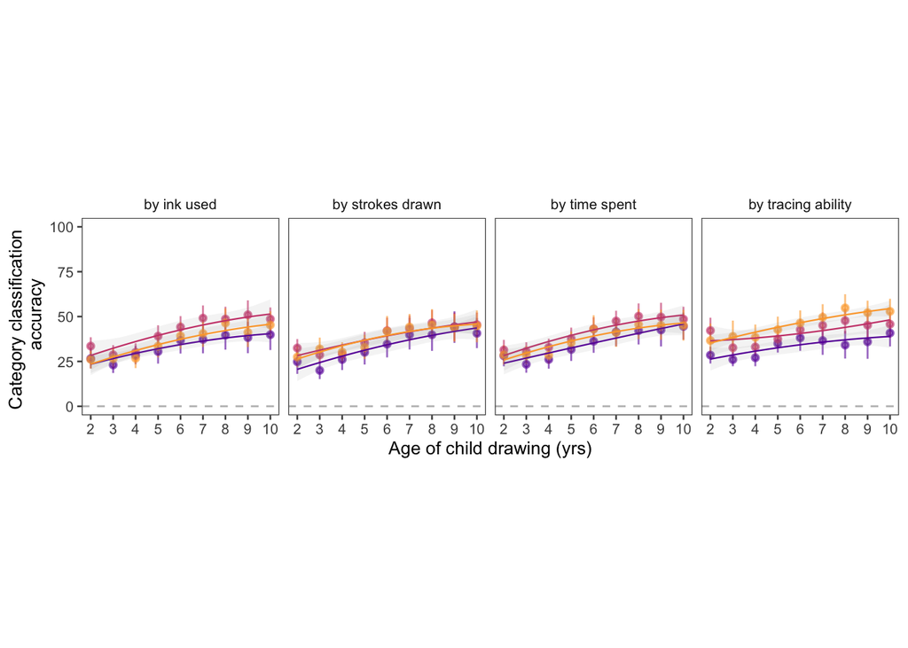

```r
smooth_alpha=.1
ggplot(merged, aes(age_numeric,mean*100, color=bin_name, group=bin_name, col=bin_name)) +
  geom_pointrange(aes(ymin = ci_lower*100, ymax = ci_upper*100), alpha=.6, size=.25) +
  theme_few(base_size = 10) +
  labs(x='Age of child drawing (yrs)', y='Category classification \n accuracy') +
  scale_color_viridis(option="C", begin=.2, end=.8, discrete=FALSE, name = 'Effort') +
  scale_x_continuous(breaks=seq(2,10,1)) +
  geom_smooth(span=10, alpha=smooth_alpha, size=.4) +
  ylim(0,100) +
  geom_hline(yintercept = 1/48, linetype="dashed", color="grey") +
  theme(legend.position ='none',aspect.ratio = 1) +
  scale_fill_discrete(labels=c('Low','Medium','High')) +
  facet_grid(~covariate)
```

```r
ggsave(here::here('data/figures_out/Appendix_A7_visuomotor_control_wide.pdf'), units='in')

write_csv(merged, here::here('data/figures_csvs/Appendix_A7_visuomotor_control_wide.csv'))
```

# Unrecognizable drawings still contain semantically relevant information

### Make long form classification data

```r
classification_data_long <- all_layer_class %>%
  filter(layer=='FC6') %>%
  mutate(correct_or_not = as.logical(correct_or_not)) %>%
  gather(key = 'class', value = 'prob', contains('prob')) %>%
  mutate(class = str_split_fixed(class, '_prob',2)[,1])
```

### Load category animacy/size (hardcoding)

```r
animacy_csv <- read_csv(here::here('data/drawings/category_metadata/animacy.csv')) %>%
  as_tibble() %>%
  mutate(animacy_size = case_when(animacy == '0' & size=='0' ~ 4, # small objects
                                  animacy == '0' & size=='1' ~ 3, # big objects
                                  animacy == '1' & size=='0' ~ 2, # small animals
                                  animacy == '1' & size=='1' ~ 1)) # big animals

## ANIM/SIZE ORDERING IS JUST ABOUT HOW YOU WANT CATEGORIES PLOTTED.
```

### Calculate avg prob by category for misclassified

```r
observations_count <- classification_data_long %>%
  filter(correct_or_not==0) %>%
  ungroup() %>%
  summarize(num_drawings = length(unique(image_name)), num_subs = length(unique(session_id)))
```

We analyzed N=13682 from 6270 that were misclassified.

```r
observations_count_clip <- d_clip %>%
  filter(correct_or_not==0) %>%
  ungroup() %>%
  summarize(num_drawings = length(unique(filename)), num_subs = length(unique(session_id)))
```

```r
confusions_by_class <- classification_data_long %>%
  mutate(drawn_category = category) %>%
  left_join(animacy_csv) %>%
  ungroup() %>%
  filter(correct_or_not==0) %>%
  mutate(drawn_category = fct_reorder(drawn_category, animacy_size)) %>%
  mutate(class = factor(class, levels = levels(drawn_category))) %>%
  group_by(drawn_category, class) %>%
  dplyr::summarize(mean_prob = mean(prob))
```

### Figure 3A: Confusions by class

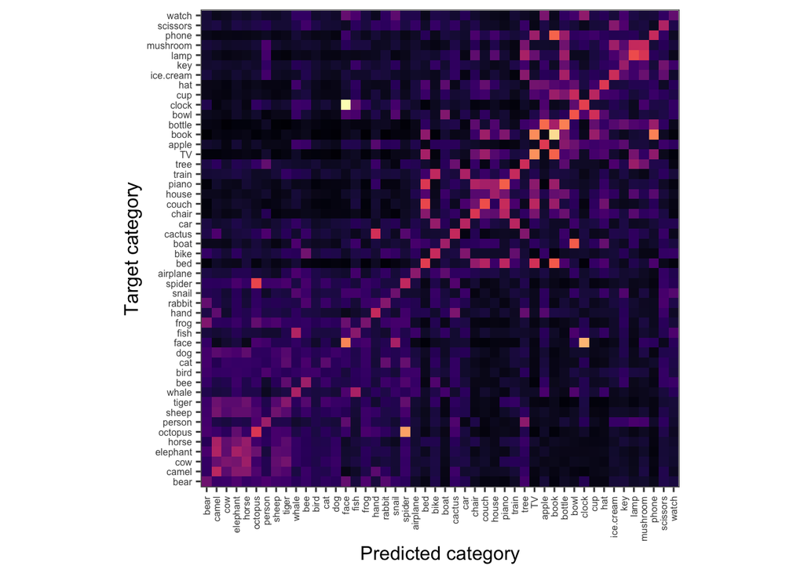

```r
ggplot(data = confusions_by_class, aes(x=class, y=drawn_category,fill=mean_prob)) +
  geom_tile() +
  theme_few(base_size = 12) +
  theme(legend.position = 'none', axis.text.x = element_text(angle = 90,
  size = 6, vjust=.5, hjust = 1), axis.text.y = element_text(angle = 0,
  size = 6, hjust = 1)) +
  coord_fixed() +
  scale_fill_viridis(option="A", name = 'Classifier probability')  +
  ylab('Target category') +
  xlab('Predicted category')
```

```r
ggsave(here::here('data/figures_out/Figure3A_classifier_confusions.pdf'), width = 7.5, height = 5, units = 'in')

write_csv(confusions_by_class, file = here::here('data/figures_csvs/Figure3A_classifier_confusions.csv'))
```

### Calculate whether animacy/size were correct

```r
animacy_size_acc_by_age <- classification_data_long %>%
  mutate(drawn_category = category) %>%
  left_join(animacy_csv %>% select(animacy, size, category), by = c("drawn_category" = "category")) %>%
  ungroup() %>%
  rename(drawn_category_animacy = animacy, drawn_category_size = size) %>%
  left_join(animacy_csv %>% select(animacy, size, category),  by = c("class" = "category")) %>%
  rename(class_animacy = animacy, class_size = size) %>%
  group_by(image_name, drawn_category, age_numeric, layer) %>%
  mutate(max_prob = max(prob), top_class = prob==max_prob)  %>%
  filter(top_class==TRUE) %>%
  mutate(animacy_correct = (drawn_category_animacy == class_animacy)) %>%
  mutate(size_correct = (drawn_category_size == class_size))
```

## Examine category variation for animacy classification

```r
baseline_animacy <- mean(animacy_csv$animacy)
baseline_objects <- 1 - mean(animacy_csv$animacy)

animacy_acc_sanity <- animacy_size_acc_by_age %>%
  filter(correct_or_not==FALSE) %>%
  group_by(category, drawn_category_animacy) %>%
  summarize(prop_animacy_correct = mean(animacy_correct)) %>%
  mutate(baseline_chance = case_when(drawn_category_animacy == 0 ~ baseline_objects,
                                     drawn_category_animacy == 1 ~ baseline_animacy)) %>%
  mutate(anim_acc = prop_animacy_correct - baseline_chance) %>%
  arrange(-anim_acc)
```

### Calculate animacy correct relative to basline

```r
baseline_animacy <- mean(animacy_csv$animacy)
baseline_objects <- 1 - mean(animacy_csv$animacy)

anim_cor_by_category_by_age <- animacy_size_acc_by_age %>%
  filter(correct_or_not==0) %>%
  mutate(drawn_category_animacy = as.factor(drawn_category_animacy))  %>%
  mutate(baseline_chance = case_when(drawn_category_animacy == 0 ~ baseline_objects,
                                     drawn_category_animacy == 1 ~ baseline_animacy)) %>%
  group_by(age_numeric, drawn_category, layer) %>%
  dplyr::summarize(avg_animacy_correct = mean(animacy_correct) - baseline_chance) %>%
  distinct(age_numeric, avg_animacy_correct, drawn_category)


anim_cor_by_age <- anim_cor_by_category_by_age %>%
  group_by(age_numeric, layer) %>%
  multi_boot_standard(col = 'avg_animacy_correct')
```

### Figure 3B: Plot animacy correct by age

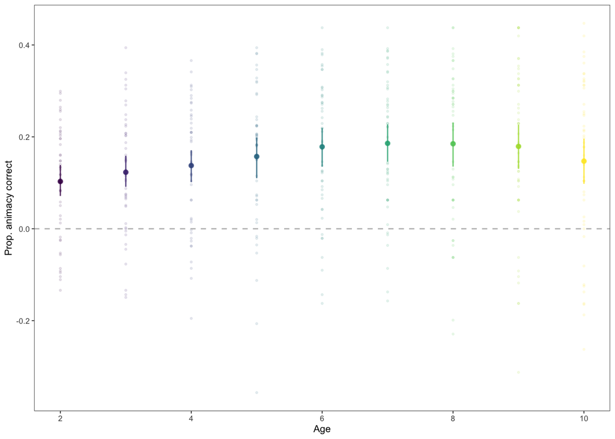

```r
smooth_alpha=.2
ggplot(anim_cor_by_age, aes(x=age_numeric,y=mean, color=age_numeric)) +
  geom_pointrange(aes(ymin = ci_lower, ymax = ci_upper), alpha=.8, size=.2) +
  geom_point(data=anim_cor_by_category_by_age, aes(x=age_numeric, y=avg_animacy_correct), alpha=.1, size=.5) +
  theme_few(base_size = 8) +
  labs(x='Age', y='Prop. animacy correct') +
  theme(legend.position = "none") +
  # geom_smooth(span=20, alpha=smooth_alpha, color='grey') +
  scale_color_viridis(option="D", discrete=FALSE) +
  geom_hline(yintercept =  0 , linetype="dashed", color="grey")
```

```r
  # facet_grid(~layer)


ggsave(here::here('data/figures_out/Figure3b_animacy_classification.pdf'), width = 1.5, height = 1.5, units = 'in')

write_csv(anim_cor_by_age, file = here::here('data/figures_csvs/Figure3b_animacy_classification.csv'))

write_csv(anim_cor_by_category_by_age, file = here::here('data/figures_csvs/Figure3b_animacy_classification_by_category.csv'))
```

```r
objects_only <- animacy_csv %>%
  filter(animacy==0)

animals_only <- animacy_csv %>%
  filter(animacy==1)

baseline_big <- mean(objects_only$size)
baseline_small <- 1 - mean(objects_only$size)

baseline_big_animals <- mean(objects_only$size)
baseline_small_animals <- 1 - mean(animals_only$size)

baseline_big_all <- mean(animacy_csv$size)
baseline_small_all <- 1 - mean(animacy_csv$size)
```

```r
size_cor_by_category_by_age <- animacy_size_acc_by_age %>%
  filter(correct_or_not==0) %>%
  # filter(animacy_correct==1) %>% # for inaniamte classifications only? doesn't matter much
  filter(drawn_category_animacy==0) %>% #only objects
  mutate(drawn_category_size = as.factor(drawn_category_size))  %>%
  mutate(baseline_chance = case_when(drawn_category_size == 0 ~ baseline_small_all,
                                     drawn_category_size == 1 ~ baseline_big_all)) %>%
  group_by(age_numeric, drawn_category, baseline_chance) %>%
  summarize(avg_size_correct = (mean(size_correct))) %>%
  mutate(avg_size_correct = avg_size_correct - baseline_chance)

size_cor_by_age <- size_cor_by_category_by_age %>%
  group_by(age_numeric) %>%
  multi_boot_standard(col = 'avg_size_correct')
```

```r
count_drawings_size <- animacy_size_acc_by_age %>%
  filter(correct_or_not==0) %>%
  filter(drawn_category_animacy==0) %>%
  summarize(num_drawings= length(unique(image_name)))
```

Not true for animal size!

```r
animal_size_cor_by_category_by_age <- animacy_size_acc_by_age %>%
  filter(correct_or_not==0) %>%
  filter(drawn_category_animacy==1) %>% #only animals
  mutate(drawn_category_size = as.factor(drawn_category_size))  %>%
  mutate(baseline_chance = case_when(drawn_category_size == 0 ~ baseline_small_animals,
                                     drawn_category_size == 1 ~ baseline_big_animals)) %>%
  group_by(age_numeric, drawn_category, baseline_chance) %>%
  summarize(avg_size_correct = (mean(size_correct))) %>%
  mutate(avg_size_correct = avg_size_correct - baseline_chance)

animal_size_cor_by_age <- animal_size_cor_by_category_by_age %>%
  group_by(age_numeric) %>%
  multi_boot_standard(col = 'avg_size_correct')
```

Look at category variation in object size classifications.

```r
size_cor_by_category <- animacy_size_acc_by_age %>%
  filter(correct_or_not==0) %>%
  filter(drawn_category_animacy==0) %>% #only objects
  mutate(drawn_category_size = as.factor(drawn_category_size))  %>%
  mutate(baseline_chance = case_when(drawn_category_size == 0 ~ baseline_small_all,
                                     drawn_category_size == 1 ~ baseline_big_all)) %>%
  group_by(drawn_category, drawn_category_size) %>%
  summarize(avg_size_correct = mean(size_correct) - baseline_chance)  %>%
  distinct(avg_size_correct, drawn_category)
```

### Figure 3C: Size correct by age

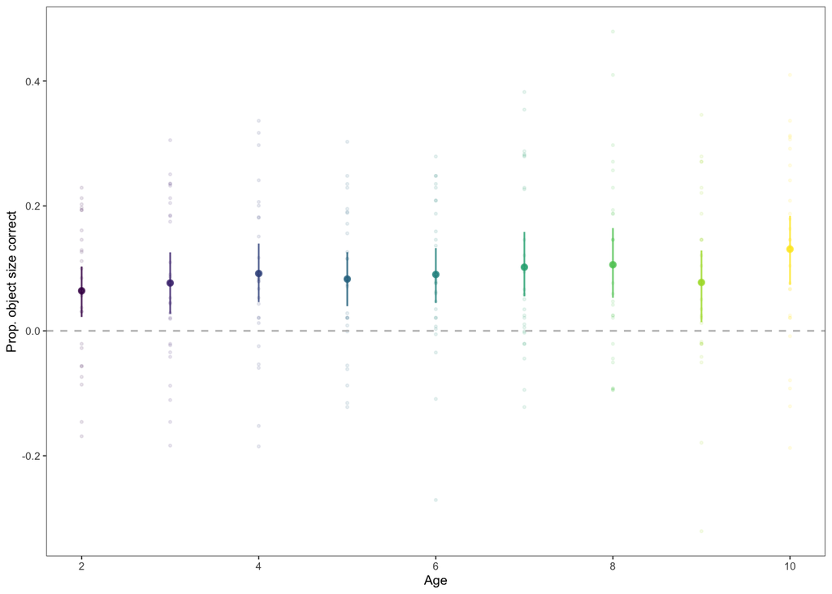

```r
ggplot(size_cor_by_age, aes(x=age_numeric,y=mean, color=age_numeric)) +
  geom_pointrange(aes(ymin = ci_lower, ymax = ci_upper), alpha=.8, size=.2) +
  geom_point(data=size_cor_by_category_by_age, aes(x=age_numeric, y=avg_size_correct), alpha=.1, size=.5) +
  theme_few(base_size = 8) +
  labs(x='Age', y='Prop. object size correct') +
  theme(legend.position = "none") +
  # geom_smooth(span=10, alpha=smooth_alpha, color='grey') +
  scale_color_viridis(option="D", discrete=FALSE) +
  geom_hline(yintercept =  0 , linetype="dashed", color="grey")
```

```r
ggsave(here::here('data/figures_out/Figure3b_size_classification.pdf'), width = 1.5, height = 1.5, units = 'in')

write_csv(size_cor_by_age, file = here::here('data/figures_csvs/Figure3b_size_classification.csv'))

write_csv(size_cor_by_category_by_age, file = here::here('data/figures_csvs/Figure3b_size_classification_each_category.csv'))
```

## Create t-tests tables if desired

```r
library(dplyr)
library(broom)
library(tibble)

animacy_tests <- anim_cor_by_category_by_age %>%
  group_by(age_numeric) %>%
  summarise(t_test_result = list(tidy(t.test(avg_animacy_correct)))) %>%
  unnest(t_test_result)


size_tests <- size_cor_by_category_by_age %>%
  group_by(age_numeric) %>%
  summarise(t_test_result = list(tidy(t.test(avg_size_correct)))) %>%
  unnest(t_test_result)  %>%
  select(-method, -alternative)
```

```r
# xtable::xtable(as.data.frame(size_tests), digits=4, caption = "Individual one-sample t-tests performed for each age over the animacy and object size classifications values for all 48 categories (aniacy) or the 25 inanimate categories (object size)")
```

# Drawings contain different semantic parts across development

```r
# all annotations before filtering
load(file = here::here('data/part_annotations_processed/merged_annotations.RData'))
```

```r
# preprocesssed emphasis data
load(file = here::here('data/part_annotations_processed/part_emphasis.RData'))
```

```r
# example drawing in presentation, or any other we want to examine
# example <- part_emphasis_all %>% filter(filename == 'bird_sketch_age8_cdm_run_v31530484377182.png')
#
# what_annotations <- d_agree_labels %>% filter(filename == 'bird_sketch_age8_cdm_run_v31530484377182.png')
```

## Get data structure with unique labels per drawing

```r
unique_labels <- d_agree_labels %>%
  group_by(filename,category, age_numeric, gameType) %>%
    summarize(count_parts = length(unique(roi_labelName)), count_unint = sum(sum(roi_labelName == 'unintelligible')>0)) %>%
  # only count unintellible as one label since looking at # of unique labels
  mutate(num_labels = count_parts - count_unint) #
```

## Plot of frequency of unique labels by category and age

```r
unique_by_age_by_category <- unique_labels %>%
  group_by(age_numeric, category) %>%
  multi_boot_standard(col = 'num_labels')

unique_by_age <- unique_labels %>%
  group_by(age_numeric) %>%
  multi_boot_standard(col = 'num_labels')
```

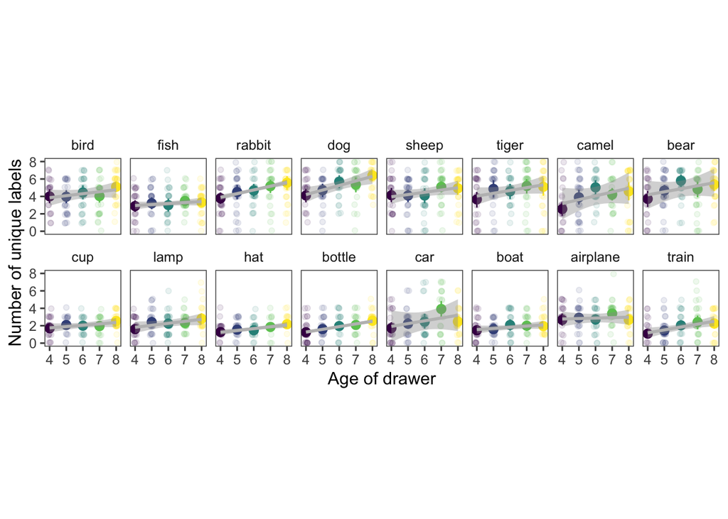

```r
ggplot(data=unique_by_age_by_category, aes(x=age_numeric, y=mean, color=age_numeric)) +
  theme_few(base_size=12) +
  geom_jitter(data = unique_labels, width=.1, height=.1, alpha=.1, aes(y=num_labels)) +
  geom_pointrange(data = unique_by_age_by_category, aes(ymin=ci_lower, ymax=ci_upper)) +
  geom_smooth(data = unique_by_age_by_category,  span=10, method='lm', color='grey') +
  scale_color_viridis_c() +
  facet_wrap(~category, nrow=2) +
  theme(legend.position='none', aspect.ratio=1) +
  ylim(0,8) +
  ylab('Number of unique labels') +
  xlab('Age of drawer')
```

```r
ggsave(here::here('data/figures_out/Appendix_A8_unique_parts_by_age.pdf'), width=8, units='in')

write_csv(unique_by_age_by_category, file = here::here('data/figures_csvs/Appendix_A8_unique_parts_by_age.csv'))
```

## Inferential: Does the number of parts change with age?

```r
### Look at age effect in lmer add bobqa optimizer to make converge (still can't get random slopes, sad)

labels_by_age <- lmer(data=unique_labels, (num_labels) ~ scale(age_numeric) + (1|category),  control=lmerControl(optimizer="bobyqa",
                                 optCtrl=list(maxfun=2e5)))

labels_by_age_out = round(summary(labels_by_age)$coefficients,3)

round(confint(labels_by_age, method='Wald'),3)
```

```
##                    2.5 % 97.5 %
## .sig01                NA     NA
## .sigma                NA     NA
## (Intercept)        2.648  3.927
## scale(age_numeric) 0.314  0.476
```

## Text: describing unique parts x age

Consistent with this idea, we found that drawings produced by older children generally contained more unique semantic parts than drawings by younger children (B=0.395, SE = 0.041, df = 2071.013, P<.001, CI=[.314, .476])

```r
img_per_category_age <- d_agree_labels %>%
  group_by(category, age_numeric) %>%
  summarize(count_images = length(unique(filename)))  %>%
  mutate(category = factor(category, levels = c("bird", "fish", "rabbit","dog" ,"sheep","tiger" ,"camel" , "bear", "cup","lamp", "hat","bottle", "car", "boat","airplane","train")))

top_parts_emphasis <- part_emphasis_all %>%
  group_by(category, roi_labelName) %>%
  filter(!roi_labelName %in% c('body','head')) %>%
  summarize(avg_emphasis = mean(emphasis), count_drawings = n()) %>%
  group_by(category) %>%
  slice_max(n=5, order_by=count_drawings)

part_emphasis_top_4_plot <- part_emphasis_all %>%
  right_join(top_parts_emphasis %>% select(category, roi_labelName)) %>%
  group_by(category, age_numeric, roi_labelName) %>%
  dplyr::summarize(avg_emphasis = mean(emphasis), count_drawings_with_part = n()) %>%
  left_join(img_per_category_age) %>%
  mutate(prop_drawings = count_drawings_with_part / count_images)
```

## Figure: Changes in part inclusion/emphasis by age

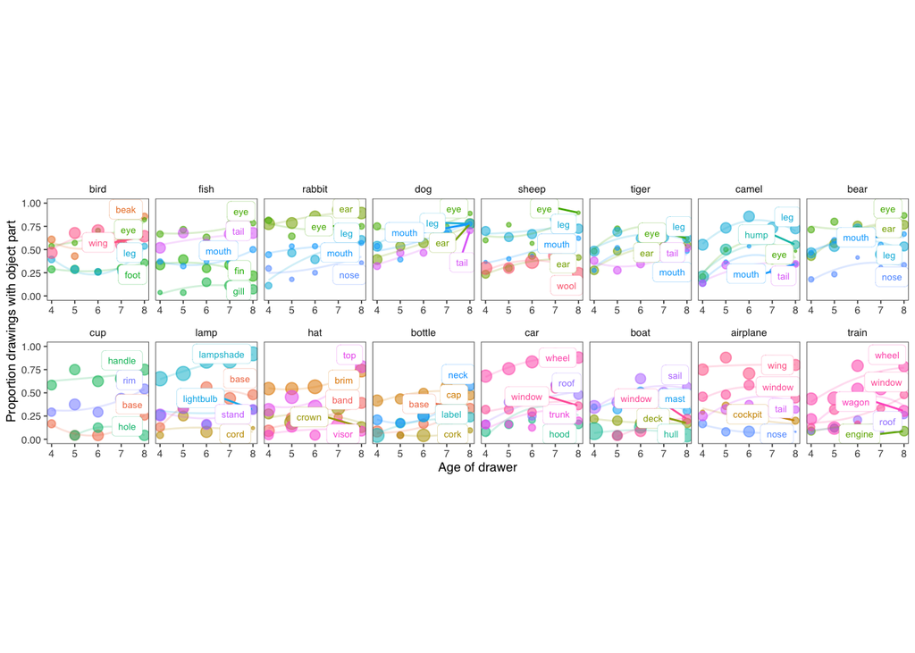

```r
ggplot(data = part_emphasis_top_4_plot, aes(x=age_numeric, y=prop_drawings, col=roi_labelName)) +
  geom_point(aes(size = avg_emphasis, alpha=.2)) +
  scale_size(range = c(0,4)) +
  theme_few(base_size=7, base_family = "Helvetica") +
  geom_line(stat='smooth',alpha=.2, span=10, aes(group=roi_labelName)) +
  ylab('Proportion drawings with object part') +
  xlab('Age of drawer') +
  theme(legend.position = 'none', aspect.ratio = 1)  +
  ylim(0,1) +
  facet_wrap(~category, nrow=2, scales = 'free_x') +
  ggrepel::geom_label_repel(data =part_emphasis_top_4_plot %>% filter(age_numeric==8), aes(label = roi_labelName), max.overlaps=10, size=1.8, label.size=.05, box.padding=0)
```

```r
ggsave(here::here('data/figures_out/Figure4_part_emphasis_by_age.pdf'),units = 'in', height = 2.5, width = 7.09)

write_csv(part_emphasis_top_4_plot, file = here::here('data/figures_csvs/Figure4_part_emphasis_by_age.csv'))
```

## Appendix Figure: Changes in object part structure with VGG 48-way classification

```r
part_emphasis_dnn_recognition <- part_emphasis_all %>%
  mutate(sketch_path = as.factor(str_split_fixed(filename,'.png',2)[,1])) %>%
  left_join(d)  %>%
  filter(!is.na(correct_or_not))

part_emphasis_clip_recognition <- part_emphasis_all %>%
  mutate(sketch_path = as.factor(str_split_fixed(filename,'.png',2)[,1])) %>%
  left_join(d_clip)  %>%
  filter(!is.na(correct_or_not))
```

```r
# some drawings were marked invalid from the set by prolific workers but not by manual exclusions, meaning that they weren't included in the 37K set.

#
# what <- part_emphasis_all %>%
#   mutate(sketch_path = as.factor(str_split_fixed(filename,'.png',2)[,1])) %>%
#   left_join(d_clip)  %>%
#   filter(is.na(correct_or_not)) %>%
#   ungroup() %>%
#   distinct(filename, category, age_numeric) %>%
#   group_by(category, age_numeric) %>%
#   summarize(num_excluded = n())
```

```r
# plus, a bunch of drawings were ecxluded from dnn classifications for balancing...annoying

# what <- part_emphasis_all %>%
#   mutate(sketch_path = as.factor(str_split_fixed(filename,'.png',2)[,1])) %>%
#   left_join(d)  %>%
#   filter(is.na(correct_or_not)) %>%
#   ungroup() %>%
#   distinct(filename, category, age_numeric) %>%
#   group_by(category, age_numeric) %>%
#   summarize(num_excluded = n())
```

```r
part_emphasis_recognition_binned <-  part_emphasis_dnn_recognition %>%
  ungroup() %>%
  group_by(category) %>% # construct bins WITHIN categories
  mutate(model_correct_bin = ntile(log_odds,4))

part_emphasis_clip_recognition_binned <-  part_emphasis_clip_recognition %>%
  ungroup() %>%
  group_by(category) %>% # construct bins WITHIN categories
  mutate(model_correct_bin = ntile(log_odds,4))
```

```r
binned_count_recognition_by_sketch <- part_emphasis_recognition_binned %>%
  group_by(category, model_correct_bin) %>%
  summarize(count_images_bin = length(unique(filename)))
```

```r
binned_count_clip_recognition_by_sketch <- part_emphasis_clip_recognition_binned %>%
  group_by(category, model_correct_bin) %>%
  summarize(count_images_bin = length(unique(filename)))
```

```r
# get emphasized parts without recognition
top_parts_emphasis <- part_emphasis_all %>%
  group_by(category, roi_labelName) %>%
  filter(!roi_labelName %in% c('body','head')) %>%
  summarize(avg_emphasis = mean(emphasis), count_drawings = n()) %>%
  group_by(category) %>%
  slice_max(n=5, order_by=count_drawings)
```

```r
part_emphasis_top_4_by_model_bin <- part_emphasis_recognition_binned %>%
  right_join(top_parts_emphasis %>% select(category, roi_labelName)) %>%
  group_by(category, model_correct_bin, roi_labelName) %>%
  dplyr::summarize(avg_emphasis = mean(emphasis), count_drawings_with_part = length(unique(filename))) %>%
  left_join(binned_count_recognition_by_sketch) %>%
  mutate(prop_drawings = count_drawings_with_part / count_images_bin)
```

```r
part_emphasis_top_4_by_clip_model_bin <- part_emphasis_clip_recognition_binned %>%
  right_join(top_parts_emphasis %>% select(category, roi_labelName)) %>%
  group_by(category, model_correct_bin, roi_labelName) %>%
  dplyr::summarize(avg_emphasis = mean(emphasis), count_drawings_with_part = length(unique(filename))) %>%
  left_join(binned_count_clip_recognition_by_sketch) %>%
  mutate(prop_drawings = count_drawings_with_part / count_images_bin)
```

```r
# part_names = unique(part_emphasis_top_4_by_model_bin$roi_labelName)

part_emphasis_top_4_by_model_bin <- part_emphasis_top_4_by_model_bin %>%
  mutate(category = factor(category, levels = c("bird", "fish", "rabbit","dog" ,"sheep","tiger" ,"camel" , "bear", "cup","lamp", "hat","bottle", "car", "boat","airplane","train")))

part_emphasis_top_4_by_clip_model_bin <- part_emphasis_top_4_by_clip_model_bin %>%
  mutate(category = factor(category, levels = c("bird", "fish", "rabbit","dog" ,"sheep","tiger" ,"camel" , "bear", "cup","lamp", "hat","bottle", "car", "boat","airplane","train")))
```

[figure not shown]

```r
ggplot(data = part_emphasis_top_4_by_model_bin, aes(x=model_correct_bin, y=prop_drawings, col=roi_labelName)) +
  geom_point(aes(size = avg_emphasis, alpha=.2)) +
  facet_wrap(~category, nrow=1) +
  theme_few(base_size=8) +
  geom_line(stat='smooth',alpha=.2, span=10) +
  ylab('Proportion drawings with object part') +
  xlab('Binned classifier evidence (VGG-19 classifications)') +
  theme(legend.position = 'none', aspect.ratio = 1)  +
  ylim(0,1) +
  facet_wrap(~category, nrow=2, scales = 'free_x') +
  scale_x_continuous(
    limits=c(.5,4.5),
    breaks=c(1,4),
    labels=c(' Low ',' High ')
        ) +
  ggrepel::geom_label_repel(data =part_emphasis_top_4_by_model_bin %>% filter(model_correct_bin==1), aes(label = roi_labelName), max.overlaps=10, size=2, box.padding=.1, label.padding=.1)
```

```r
ggsave(here::here('data/figures_out/Appendix_A9_part_emphasis_by_model_bin.pdf'),units = 'in', height = 3, width = 8)

write_csv(part_emphasis_top_4_by_model_bin, file = here::here('data/figures_csvs/Appendix_A9_part_emphasis_by_model_bin.csv'))
```

## Not included in Appendix, parts by CLIP model here for completeness.

[figure not shown]

```r
ggplot(data = part_emphasis_top_4_by_clip_model_bin, aes(x=model_correct_bin, y=prop_drawings, col=roi_labelName)) +
  geom_point(aes(size = avg_emphasis, alpha=.2)) +
  scale_size_area() +
  facet_wrap(~category, nrow=1) +
  theme_few(base_size=8) +
  geom_line(stat='smooth',alpha=.2, span=10) +
  ylab('Proportion drawings with object part') +
  xlab('Binned classifier evidence (CLIP classifications)') +
  theme(legend.position = 'none', aspect.ratio = 1)  +
  ylim(0,1) +
  facet_wrap(~category, nrow=2, scales = 'free_x') +
  scale_x_continuous(
    limits=c(.5,4.5),
    breaks=c(1,4),
    labels=c(' Low ',' High ')
        ) +
  ggrepel::geom_label_repel(data =part_emphasis_top_4_by_clip_model_bin %>% filter(model_correct_bin==1), aes(label = roi_labelName), max.overlaps=10, size=2, box.padding=.1, label.padding=.1)
```

**R version 4.3.1 (2023-06-16)**

**Platform:** x86_64-apple-darwin20 (64-bit)

**locale:** en_US.UTF-8||en_US.UTF-8||en_US.UTF-8||C||en_US.UTF-8||en_US.UTF-8

**attached base packages:** *stats*, *graphics*, *grDevices*, *utils*, *datasets*, *methods* and *base*

**other attached packages:** *broom(v.1.0.5)*, *performance(v.0.10.5)*, *pander(v.0.6.5)*, *langcog(v.0.1.9001)*, *lmerTest(v.3.1-3)*, *lme4(v.1.1-34)*, *Matrix(v.1.6-1)*, *viridis(v.0.6.4)*, *viridisLite(v.0.4.2)*, *ggthemes(v.4.2.4)*, *assertthat(v.0.2.1)*, *here(v.1.0.1)*, *lubridate(v.1.9.2)*, *forcats(v.1.0.0)*, *stringr(v.1.5.0)*, *dplyr(v.1.1.2)*, *purrr(v.1.0.2)*, *readr(v.2.1.4)*, *tidyr(v.1.3.0)*, *tibble(v.3.2.1)*, *ggplot2(v.3.4.3)* and *tidyverse(v.2.0.0)*

**loaded via a namespace (and not attached):** *tidyselect(v.1.2.0)*, *farver(v.2.1.1)*, *fastmap(v.1.1.1)*, *lazyeval(v.0.2.2)*, *digest(v.0.6.33)*, *rpart(v.4.1.19)*, *timechange(v.0.2.0)*, *lifecycle(v.1.0.3)*, *cluster(v.2.1.4)*, *magrittr(v.2.0.3)*, *compiler(v.4.3.1)*, *rlang(v.1.1.1)*, *Hmisc(v.5.1-1)*, *sass(v.0.4.7)*, *tools(v.4.3.1)*, *utf8(v.1.2.3)*, *yaml(v.2.3.7)*, *data.table(v.1.14.8)*, *knitr(v.1.43)*, *labeling(v.0.4.2)*, *htmlwidgets(v.1.6.2)*, *bit(v.4.0.5)*, *withr(v.2.5.0)*, *foreign(v.0.8-84)*, *numDeriv(v.2016.8-1.1)*, *nnet(v.7.3-19)*, *grid(v.4.3.1)*, *fansi(v.1.0.4)*, *xtable(v.1.8-4)*, *colorspace(v.2.1-0)*, *scales(v.1.2.1)*, *MASS(v.7.3-60)*, *insight(v.0.19.6)*, *cli(v.3.6.1)*, *rmarkdown(v.2.24)*, *crayon(v.1.5.2)*, *ragg(v.1.2.5)*, *generics(v.0.1.3)*, *rstudioapi(v.0.15.0)*, *tzdb(v.0.4.0)*, *minqa(v.1.2.5)*, *cachem(v.1.0.8)*, *splines(v.4.3.1)*, *parallel(v.4.3.1)*, *base64enc(v.0.1-3)*, *vctrs(v.0.6.3)*, *boot(v.1.3-28.1)*, *jsonlite(v.1.8.7)*, *hms(v.1.1.3)*, *ggrepel(v.0.9.3)*, *bit64(v.4.0.5)*, *Formula(v.1.2-5)*, *htmlTable(v.2.4.1)*, *systemfonts(v.1.0.4)*, *jquerylib(v.0.1.4)*, *glue(v.1.6.2)*, *nloptr(v.2.0.3)*, *stringi(v.1.7.12)*, *gtable(v.0.3.4)*, *munsell(v.0.5.0)*, *pillar(v.1.9.0)*, *htmltools(v.0.5.6)*, *R6(v.2.5.1)*, *textshaping(v.0.3.6)*, *rprojroot(v.2.0.3)*, *vroom(v.1.6.3)*, *evaluate(v.0.21)*, *lattice(v.0.21-8)*, *highr(v.0.10)*, *backports(v.1.4.1)*, *bslib(v.0.5.1)*, *Rcpp(v.1.0.11)*, *gridExtra(v.2.3)*, *nlme(v.3.1-162)*, *checkmate(v.2.2.0)*, *mgcv(v.1.8-42)*, *xfun(v.0.40)* and *pkgconfig(v.2.0.3)*